# Welcome to CRSS 8030 Data Science Applied to Ag!

Spring 2025

Dr. Leo Bastos

## Teaching team

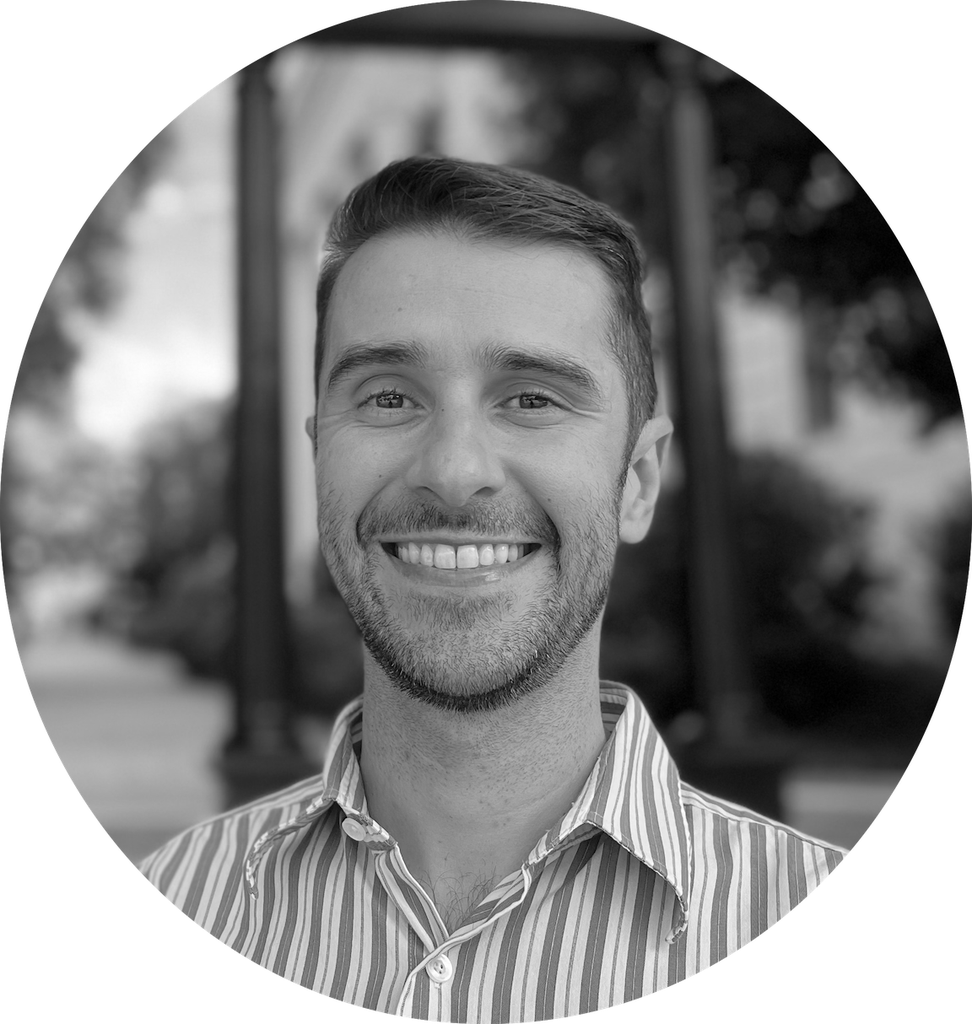

Dr. Leonardo M. Bastos

Assistant Professor  
4101 Miller Plant Sciences Building  
UGA-Athens Campus  
Email: `lmbastos@uga.edu`

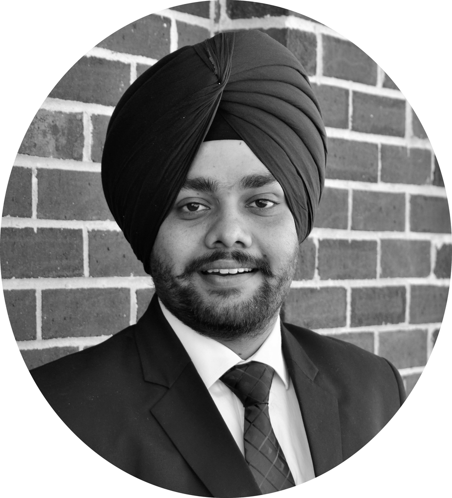

Amrinder Jakhar

PhD student  
Miller Plant Sciences Building  
UGA-Athens Campus  
Email: `Amrinderjakhar@uga.edu`

## Office hours

- The TA office hours are **Monday and Thursday** from **2 to 4 pm**, upon appointment.
- If you need assistance, please email Amrinder to get a time scheduled within the windows above.
- Always start seeking help by posting on GitHub (more on this later), and only then reach out to Amrinder.

# Syllabus rundown

Full syllabus can be found [here](https://leombastos.github.io/bastoslab/teaching/2025-dsa/2025-dsa.html#course-syllabus)

## Meeting times and locations

Time:

- **Lectures**: Tuesdays at 09:30-11:10
- **Labs**: Thursdays at 09:30-11:30

Location:

- **Athens** campus: in person at 1203 Miller
- **Tifton** campus: in person at 601 NESPAL South OR remote
- **Griffin** campus: in person at SLC UGA Computer lab OR remote

Zoom credentials shared via email.

## Course objectives

1. Learning and applying analytical workflows that involve importing data, processing, analyzing, assessing model fit, extracting model information and producing publication-ready figures for different analysis including ANOVAs and regression

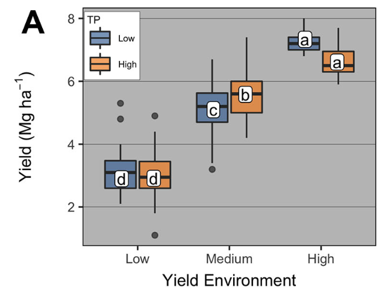

## Course objectives

2. Conducting analysis of variance workflows for the most commonly used agricultural designed studies (completely randomized design, randomized complete block design, split-plot design)

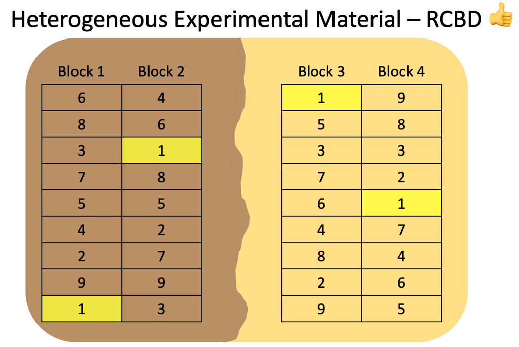

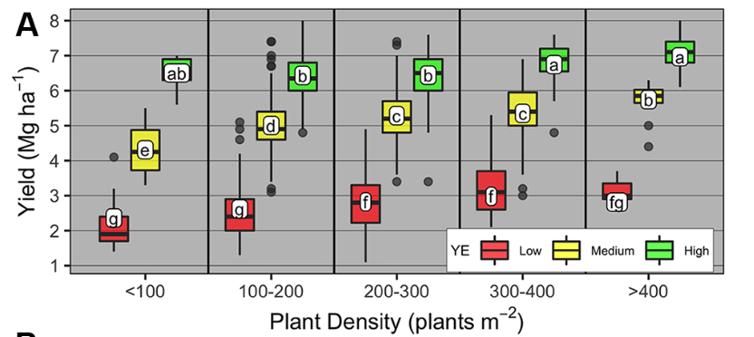

## Course objectives

3. Conducting linear and non-linear regression workflows

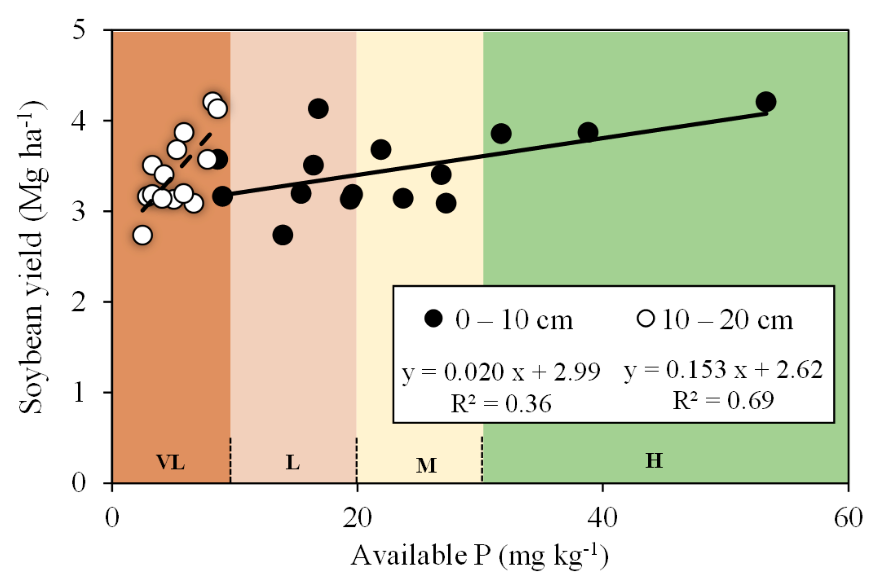

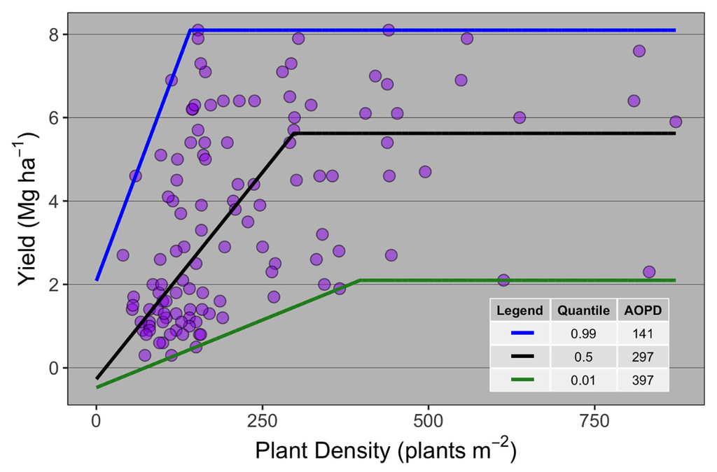

## Course objectives

4. Learning and applying machine learning concepts (bias-variance trade-off, data split, hyper-parameter optimization, predictive metrics) and algorithms to agricultural observational data (soils, weather, yield)

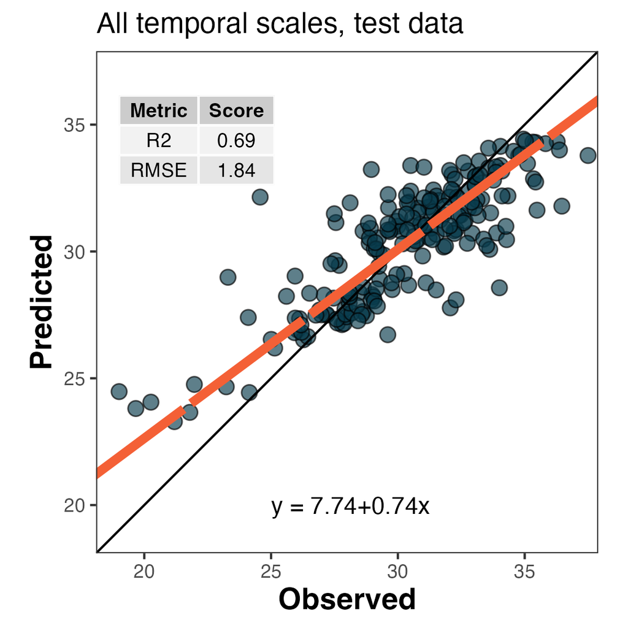

## Course objectives

5. Learning and applying machine learning concepts (bias-variance trade-off, data split, hyper-parameter optimization, predictive metrics) and algorithms to agricultural observational data (soils, weather, yield)

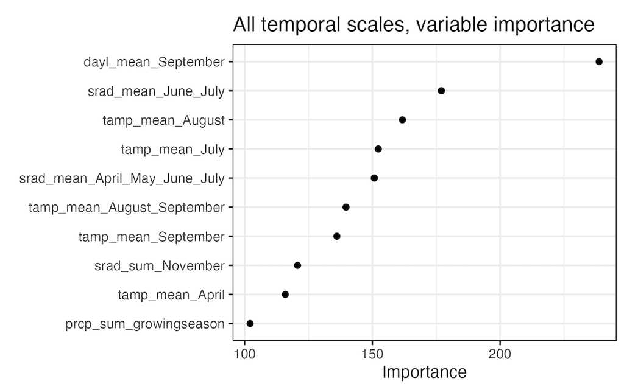

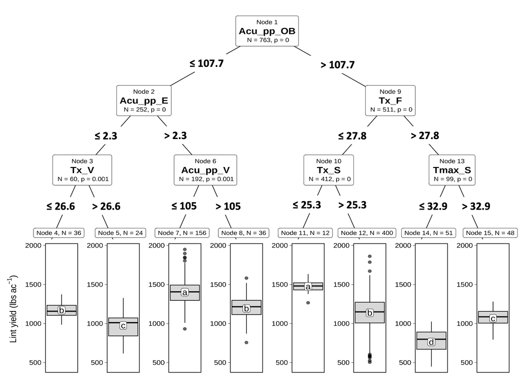

## Course objectives

6. Doing all the above while learning and using data science tools for reproducibility like version control, statistical programming, APIs to publicly available data sets, task automation, and creating online interactive dashboards.

[figure not shown]

[figure not shown]

## Course objectives

7. All steps will be conducted utilizing the **R statistical language** to create modern, well documented and reproducible analytical workflows. No previous knowledge in R is required.

[figure not shown]

## Course objectives

For example, predicting cotton yield across the cotton belt using open-source weather data

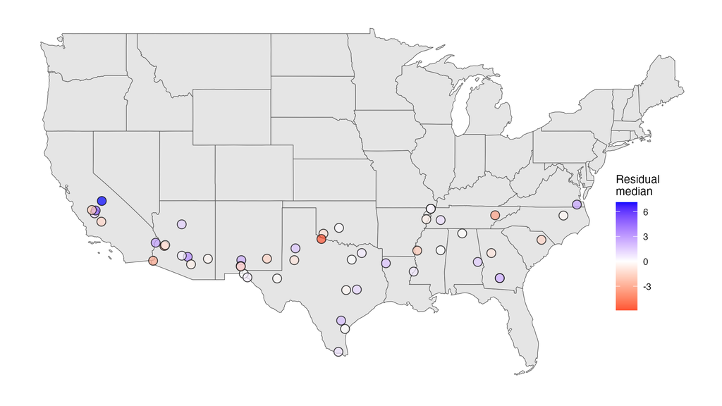

## Course topics

This course will be split into **two** main parts:

- Planing, designing, and analysis of **experimental designs**
- Data scraping and feature engineering for **machine learning**

All intertwined with **data science concepts** with a focus on agricultural case studies

## Course topics - Experimental design

1. Intro to R and RStudio
2. git and GitHub
3. R APIs to open data (USDA NASS, weather, soil)
4. Data wrangling with dplyr, tidyr, pipe operator
5. Data visualization with ggplot2, gganimate
6. Experimental unit, randomization, and replication
7. Exp. and trt. designs and ANOVAs
8. Fixed vs. Random effects
9. Repeated measures
10. Automating repetitive tasks through iteration with purrr

## Course topics - Machine learning

11. Linear regression
12. Non-linear regression
13. Regression for finding optimum
14. Dimensionality reduction
15. Machine learning concepts
    1. Bias-variance trade-off
    2. Data split
    3. Hyperparameter opt.
    4. Predictive assessment
16. Machine learning models
    1. K-means (unsupervised)
    2. Tree models (RF, CIT)
    3. XGboost
17. Dashboards
    1. Creating a simple dashboard with shiny apps
    2. Publishing a dashboard online

All classes will be recorded and further posted on the class YouTube channel.

This should be used as a supporting study tool and make-up for content from missed classes. **Recordings do not replace in-person/remote attendance**.

## Assessment and Grading

| Activity | Grade |
| --- | --- |
| Mid-term project: Experimental data analysis | 10% |
| Mid-term exam | 10% |
| Homework assignments | 35% |
| In-class quizzes | 15% |
| Final project: Machine learning | 20% |
| Class participation | 10% |

## Course website

Important links related to this course:

- [Course website](https://leombastos.github.io/bastoslab/teaching/2025-dsa/2025-ppa.html)
- [Course GitHub repository](https://github.com/leombastos/2025_dsa)
- [Course YouTube channel](https://www.youtube.com/@agronomyR/videos)

## Course website - downloading slides

1. With the slides page open on your browser, push `e` on your keyboard.
2. On your browser, go to `File > Print`.
3. Adjust orientation and pages per sheet if desired.
4. Save as PDF.

## Course website - asking questions

- If your question is related to **difficulties with material/code/assignments**, then post it on our class GitHub page on the `Issues` tab.
- Go to the class [GitHub repository](https://github.com/leombastos/2025_dsa) > Click on `Issues` (near top left) > Click on `New issue` (green button) > Give it a descriptive title, leave your comment > Click on `Submit new issue`.

## Course website - asking questions

By asking questions on GitHub, other students may be able to help you besides only instructor.

**Helping others on GitHub will count as participation!**

## Course website - asking questions

- Let’s try it out: introductions (may need to sign up to GitHub)
  - First and last name
  - Department
  - Degree (MS or PhD)
  - Area of research

## Attendance policy

Students are expected to attend every class period.

Students on the **Athens campus** must attend class in-person.

If a special circumstance arise (illness, travel, etc.), student absence or remote attendance **must be informed to instructors prior to that class period**.

## Attendance policy

Students are expected to attend every class period.

Students on the **Tifton and Griffin campuses** may attend class in-person on their campuses or remote using the zoom link information.

Student absence **must be informed to instructors prior to that class period to be excused**.

## Attendance policy

Students are expected to attend every class period.

**Puncuality is important!**  
Students **>3 min late** will be asked to leave and recorded as a missed class.  
If special circumstances arise, please reach out to me in advance to accommodate for it.

## Attendance policy

Students are expected to attend every class period.

Per Board of Regents policy, I reserve the right to drop students from the class roll who **miss more than 5 class periods**. Such students will be given a WF grade.

## Attendance policy

When attending a class remotely via zoom, students are expected to have **cameras on at all times**.

## Technology and software requirements

Students will need to have access to:

- A computer 💻 (to install software, code along with instructors)
- A second screen 📺 (main screen to code along, second screen to watch class if not in person)

If a student does not have access to these resources (personal laptop/desktop and a second screen), please let instructors know to ensure proper accommodations can be made.

## AI, LLMs, and plagiarism

You are allowed to use LLMs like ChatGPT on your coding assignments, as long as

- you use it to learn, not to simply copy/paste
- you give appropriate credit

**Plagiarism, both from your classmates AND LLMs, is a serious violation of code of conduct and will be reported to university officials**

## Survey

Please go to the link below and fill this survey:

https://forms.gle/NtTVZN5SGAHFyALL7

Take 5 minutes to answer it.

## Getting ready for next class

To be ready for next class (**Intro to R**), please go to the course main page and follow the link to the `Lab 01 prep` page.

If you have questions or issues, email the TA and cc me **before class**.

We will have limited time to troubleshoot technical problems during next period.

# Thanks, and see you on Thursday!